# Implementing culling

Kate Royce

### Introduction

The goal of this document is to determine what culling scenario returns the simulation to baseline after one infection.

The following parameters determine the scenario:

- Critical surveillance time, $\tau$-crit
- Threshold for reporting, $I$-crit
- Reporting probability, $\pi$-report
- Detection probability, $\pi$-detect

The simulation also inherits the following options from experiment 4:

- Non-linear Contact Rate ($\rho, \beta$)
- Clustered Intensification in Growth Scenario
- Paired Networks: Initial / Growth Scenarios have same set of stochastic networks
- Poisson distribution with 40 as mean number of chickens per farm
- 100 Farms
- One initial seeded infection

#### Parameters

$\beta$ = 1.4456 – Contact rate implemented alongside $\rho$

$\gamma$ = 0.167 – Recovery rate

$\mu$ = 0.0 – Base mortality rate

$\alpha$ = 0.4 – Disease mortality rate

$\phi$ = 0.0 – Infectiousness of environmental virions

$\eta$ = 0.0 – Degradation of environmental virions

$\nu$ = 0.0 – Update rate of environmental virions

$\sigma$ = 0.0 – Virion shedding rate

$\omega$ = 0.03 – Inter-patch movement rate

$\rho$ = 0.8526 – Contact non-linearity parameter

$\lambda$ = 0.0 – External force of infection

$\tau$-crit = 1.0 – Critical surveillance time

$I$-crit = 5.0 – Threshold for reporting

$\pi$-report = 0.9 – Reporting probability

$\pi$-detect = 0.9 – Detection probability

### Initial Run

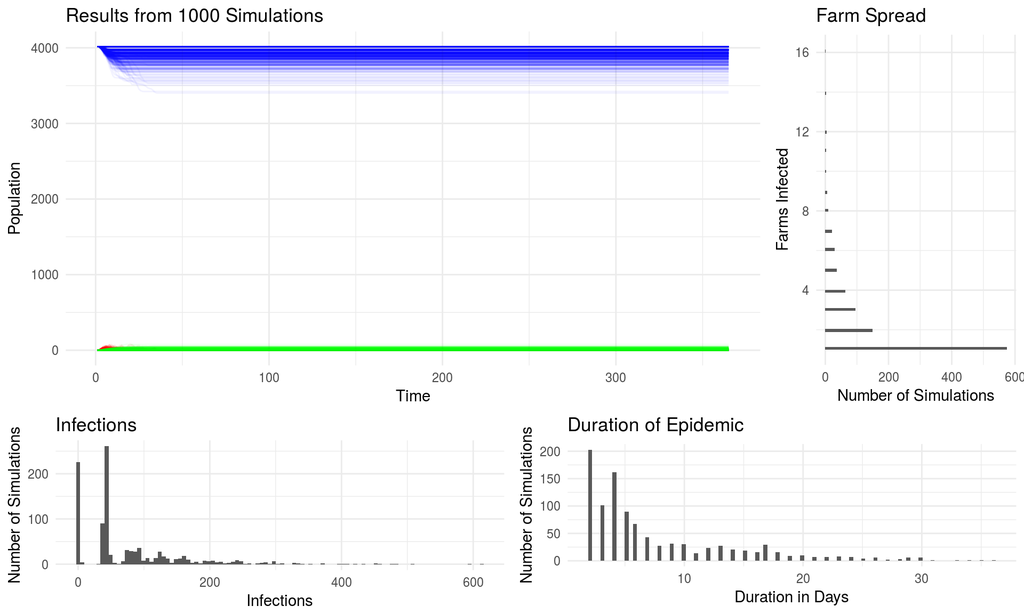

### Growth Run

Eleven percent of farms have grown in size by an order of magnititude, resulting in the doubling of total chicken population in the system. This intensification occurs in the same region.

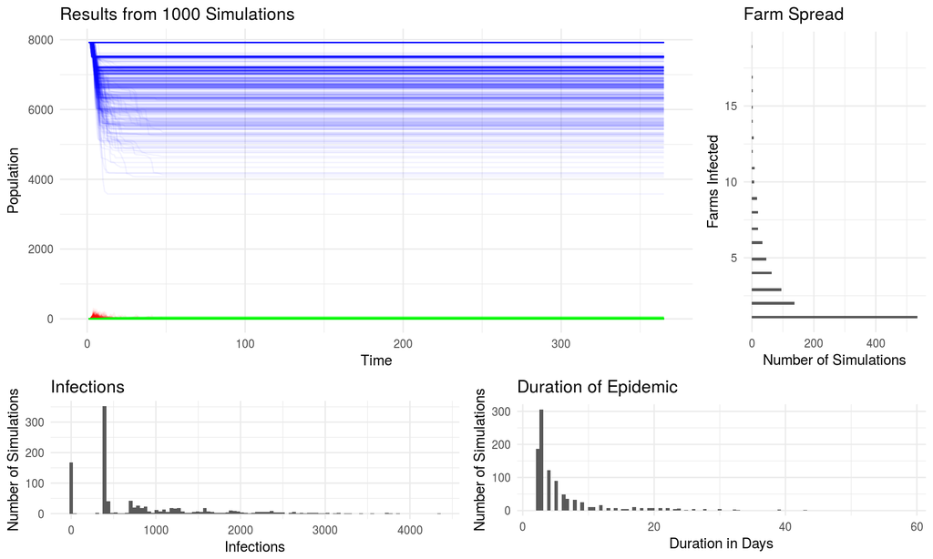